# Random Forest Demo

Souad Guemghar

16 February 2021

This demo is based on StatQuest’s video https://www.youtube.com/watch?v=6EXPYzbfLCE&t=13s and the accompanying R code **rcode_statQuest_random_forest_demo.R**

```r
library(dplyr)
library(tidyr) # for pivot_longer
library(ggplot2)
library(cowplot) # improves some of ggplot's default settings, overwites ggsave
library(randomForest)
```

## Load data

The data used in this demo comes from the UCI machine learning repository http://archive.ics.uci.edu/ml/index.php Specifically, this is the heart disease data set http://archive.ics.uci.edu/ml/datasets/Heart+Disease

```
## 'data.frame':    303 obs. of  14 variables:
##  $ V1 : num  63 67 67 37 41 56 62 57 63 53 ...
##  $ V2 : num  1 1 1 1 0 1 0 0 1 1 ...
##  $ V3 : num  1 4 4 3 2 2 4 4 4 4 ...
##  $ V4 : num  145 160 120 130 130 120 140 120 130 140 ...
##  $ V5 : num  233 286 229 250 204 236 268 354 254 203 ...
##  $ V6 : num  1 0 0 0 0 0 0 0 0 1 ...
##  $ V7 : num  2 2 2 0 2 0 2 0 2 2 ...
##  $ V8 : num  150 108 129 187 172 178 160 163 147 155 ...
##  $ V9 : num  0 1 1 0 0 0 0 1 0 1 ...
##  $ V10: num  2.3 1.5 2.6 3.5 1.4 0.8 3.6 0.6 1.4 3.1 ...
##  $ V11: num  3 2 2 3 1 1 3 1 2 3 ...
##  $ V12: chr  "0.0" "3.0" "2.0" "0.0" ...
##  $ V13: chr  "6.0" "3.0" "7.0" "3.0" ...
##  $ V14: int  0 2 1 0 0 0 3 0 2 1 ...
```

The columns are not labelled, we rename with labels from the UCI website.

```
##   age sex cp trestbps chol fbs restecg thalach exang oldpeak slope  ca thal hd
## 1  63   1  1      145  233   1       2     150     0     2.3     3 0.0  6.0  0
## 2  67   1  4      160  286   0       2     108     1     1.5     2 3.0  3.0  2
## 3  67   1  4      120  229   0       2     129     1     2.6     2 2.0  7.0  1
## 4  37   1  3      130  250   0       0     187     0     3.5     3 0.0  3.0  0
## 5  41   0  2      130  204   0       2     172     0     1.4     1 0.0  3.0  0
## 6  56   1  2      120  236   0       0     178     0     0.8     1 0.0  3.0  0
```

```
## 'data.frame':    303 obs. of  14 variables:
##  $ age     : num  63 67 67 37 41 56 62 57 63 53 ...
##  $ sex     : num  1 1 1 1 0 1 0 0 1 1 ...
##  $ cp      : num  1 4 4 3 2 2 4 4 4 4 ...
##  $ trestbps: num  145 160 120 130 130 120 140 120 130 140 ...
##  $ chol    : num  233 286 229 250 204 236 268 354 254 203 ...
##  $ fbs     : num  1 0 0 0 0 0 0 0 0 1 ...
##  $ restecg : num  2 2 2 0 2 0 2 0 2 2 ...
##  $ thalach : num  150 108 129 187 172 178 160 163 147 155 ...
##  $ exang   : num  0 1 1 0 0 0 0 1 0 1 ...
##  $ oldpeak : num  2.3 1.5 2.6 3.5 1.4 0.8 3.6 0.6 1.4 3.1 ...
##  $ slope   : num  3 2 2 3 1 1 3 1 2 3 ...
##  $ ca      : chr  "0.0" "3.0" "2.0" "0.0" ...
##  $ thal    : chr  "6.0" "3.0" "7.0" "3.0" ...
##  $ hd      : int  0 2 1 0 0 0 3 0 2 1 ...
```

We need to clean up the data, by conveting “?” inot **NA**, converting **sex** into a **factor** with levels **F** for 0 (female) and **M** for 1 (male).

```
## 'data.frame':    303 obs. of  14 variables:
##  $ age     : num  63 67 67 37 41 56 62 57 63 53 ...
##  $ sex     : Factor w/ 2 levels "F","M": 2 2 2 2 1 2 1 1 2 2 ...
##  $ cp      : Factor w/ 4 levels "1","2","3","4": 1 4 4 3 2 2 4 4 4 4 ...
##  $ trestbps: num  145 160 120 130 130 120 140 120 130 140 ...
##  $ chol    : num  233 286 229 250 204 236 268 354 254 203 ...
##  $ fbs     : Factor w/ 2 levels "0","1": 2 1 1 1 1 1 1 1 1 2 ...
##  $ restecg : Factor w/ 3 levels "0","1","2": 3 3 3 1 3 1 3 1 3 3 ...
##  $ thalach : num  150 108 129 187 172 178 160 163 147 155 ...
##  $ exang   : Factor w/ 2 levels "0","1": 1 2 2 1 1 1 1 2 1 2 ...
##  $ oldpeak : num  2.3 1.5 2.6 3.5 1.4 0.8 3.6 0.6 1.4 3.1 ...
##  $ slope   : Factor w/ 3 levels "1","2","3": 3 2 2 3 1 1 3 1 2 3 ...
##  $ ca      : Factor w/ 4 levels "0","1","2","3": 1 4 3 1 1 1 3 1 2 1 ...
##  $ thal    : Factor w/ 3 levels "3","6","7": 2 1 3 1 1 1 1 1 3 3 ...
##  $ hd      : Factor w/ 2 levels "Healthy","Unhealthy": 1 2 2 1 1 1 2 1 2 2 ...
```

## Missing data imputation

The first output column **OOB** is the Out-Of-Bag error which should improve with iterations. If it doesn’t then tells us the estimate is as good as it will ever get with this method.

```r
set.seed(42) # for reproducible results
data.imputed <- rfImpute(hd ~ ., data = data, iter = 2)
```

```
## ntree      OOB      1      2
##   300:  17.49% 12.80% 23.02%
## ntree      OOB      1      2
##   300:  16.83% 14.02% 20.14%
```

## The model

Build a random forest with imputed data and return a proximity table.

```
##
## Call:
##  randomForest(formula = hd ~ ., data = data.imputed, proximity = TRUE)
##                Type of random forest: classification
##                      Number of trees: 500
## No. of variables tried at each split: 3
##
##         OOB estimate of  error rate: 18.48%
## Confusion matrix:
##           Healthy Unhealthy class.error
## Healthy       141        23   0.1402439
## Unhealthy      33       106   0.2374101
```

Default settings are:

- 500 trees
- Number of variables per split:
  - **Classification trees** square root of of the number of variables ($\sqrt{13} =$ 3.6055513)
  - **Regression trees** a third of the number of variables.

### Optimising number of trees

Each row reflects the error rates at different stages of creating the random forest. The first row error rates after 1st tree, 2nd row contains the error rates after the first 2 trees, the nth row contains the error rates after making the first *n* trees.

```
## # A tibble: 6 x 3
##   Trees Type      Error
##   <int> <chr>     <dbl>
## 1     1 Unhealthy 0.269
## 2     2 Unhealthy 0.265
## 3     3 Unhealthy 0.208
## 4     4 Unhealthy 0.25
## 5     5 Unhealthy 0.220
## 6     6 Unhealthy 0.271
```

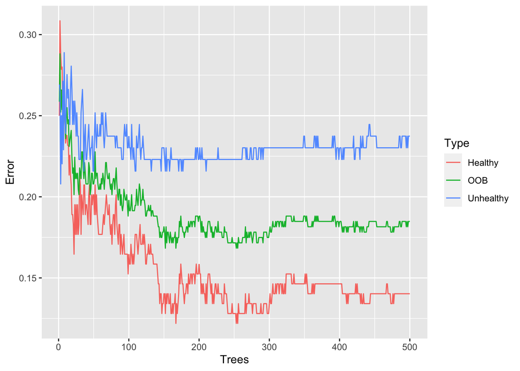

The blue line shows the error rate when classifying unhealthy patients. The green line shows the overall OOB error rate. The red line shows the error rate when classifying healthy patients. The error tendency is decreasing. Would this continue with a larger number of trees? Let us increase the number of trees and generate a new forest. The *randomForest* variable controlling the number of trees is *ntree*.

```r
model <- randomForest(hd ~ ., data = data.imputed, ntree = 1000, proximity = TRUE)
model
```

```
##
## Call:
##  randomForest(formula = hd ~ ., data = data.imputed, ntree = 1000,      proximity = TRUE)
##                Type of random forest: classification
##                      Number of trees: 1000
## No. of variables tried at each split: 3
##
##         OOB estimate of  error rate: 16.5%
## Confusion matrix:
##           Healthy Unhealthy class.error
## Healthy       143        21   0.1280488
## Unhealthy      29       110   0.2086331
```

```
## # A tibble: 6 x 3
##   Trees Type      Error
##   <int> <chr>     <dbl>
## 1     1 Unhealthy 0.423
## 2     2 Unhealthy 0.345
## 3     3 Unhealthy 0.365
## 4     4 Unhealthy 0.351
## 5     5 Unhealthy 0.365
## 6     6 Unhealthy 0.344
```

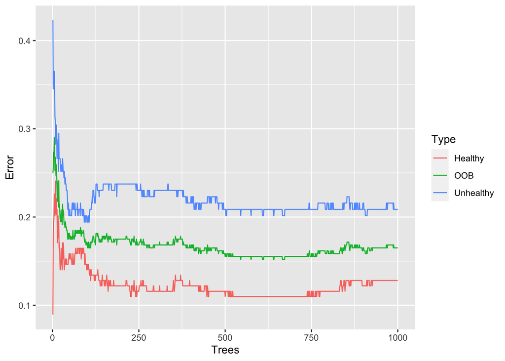

Adding more trees does not help improve the error, but we can only know this if we make more trees.

### Optimising number of variables per split

The *randomForest* variable controlling the number of random variables at each split is *mtry*. Below we look at the **OOB** error rate for different values of **mtry**.

```r
oob.values <- NULL
m <- 12
oob.values1 <- vector(length = m)
for(i in 1:m) {
  temp.model <- randomForest(hd ~ ., data = data.imputed, mtry = i, ntree = 1000)
  oob.values <- as.data.frame(temp.model$err.rate) %>%
    select(OOB) %>%
    slice_tail() %>%
    bind_rows(oob.values, .)
    oob.values1[i] <- temp.model$err.rate[nrow(temp.model$err.rate),1]
}
oob.values <- oob.values[, 1]
oob.values1
```

```
##  [1] 0.1782178 0.1683168 0.1650165 0.1716172 0.1749175 0.1848185 0.1848185
##  [8] 0.1815182 0.1947195 0.1815182 0.1848185 0.1980198
```

```r
all.equal(oob.values, oob.values1)
```

```
## [1] TRUE
```

```r
## find the minimum error
min(oob.values)
```

```
## [1] 0.1650165
```

```r
## find the optimal value for mtry...
max(which(oob.values == min(oob.values)))
```

```
## [1] 3
```

```r
## create a model for proximities using the best value for mtry
model <- randomForest(hd ~ .,
                      data=data.imputed,
                      ntree = 1000,
                      proximity = TRUE,
                      mtry = max(which(oob.values == min(oob.values))))

model
```

```
##
## Call:
##  randomForest(formula = hd ~ ., data = data.imputed, ntree = 1000,      proximity = TRUE, mtry = max(which(oob.values == min(oob.values))))
##                Type of random forest: classification
##                      Number of trees: 1000
## No. of variables tried at each split: 3
##
##         OOB estimate of  error rate: 16.5%
## Confusion matrix:
##           Healthy Unhealthy class.error
## Healthy       142        22   0.1341463
## Unhealthy      28       111   0.2014388
```

### MDS plot of samples

See StatQuest video on MDS plots.

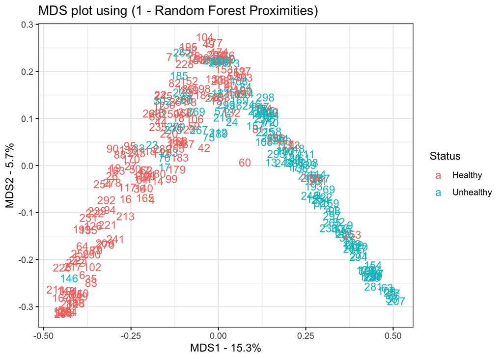